# PHYS116_LN7

[output not shown]

Suppose we have a function that is *not* periodic, and the domain of interest is all real numbers $(-\infty,\infty)$. Recall that on any *finite* interval of length $L$, we could represent any function by its Fourier series, and the series converges to the original function everywhere except the endpoints of the interval.

So by taking $L \rightarrow \infty$, we can accurately represent our arbitrary function at all finite $x$.

Let's use the complex Fourier series:

Let $\Delta q = 2 \pi /L$. Then

\begin{align*} f(x) &= \frac{\Delta q}{2\pi} \sum_{n=-\infty}^\infty \int_{-L/2}^{L/2} du f(u) e^{n \Delta q i(x-u)} \end{align*}

Now, instead of summing over all integers $n$, we are going to divide the *real* number line into intervals of length $\Delta q$. The $n$th interval is centered at $$ q_n \equiv n \Delta q$$

\begin{align*} f(x) &= \frac{1}{2\pi} \sum_{n=-\infty}^\infty \Delta q \int_{-L/2}^{L/2} du f(u) e^{q_n i (x-u)} \end{align*}

As $L\rightarrow \infty$, $\Delta q = 2\pi /L \rightarrow 0$ and so the sum $$\sum_{n=-\infty}^\infty \Delta q \text{[function of $q_n$]}$$ becomes $$\int_{-\infty}^\infty dq_n \text{[function of $q_n$]}$$ We have no more need for $n$, so let's use $q$ in place of $q_n$. We'll also replace $+\pm L/2$ with $\pm \infty$.

\begin{align*} f(x) &= \frac{1}{2\pi} \int_{-\infty}^\infty dq \int_{-\infty}^\infty du f(u) e^{iq(x-u)} \\ &= \frac{1}{2\pi} \int_{-\infty}^\infty dq e^{iqx} \int_{-\infty}^\infty du e^{-iqu} \end{align*}

Define $$ \tilde f(q) \equiv \frac{1}{2\pi} \int_{-\infty}^\infty du f(u) e^{-iqu}. $$ (We could use $u$ instead of $x$ here, since the variable being integrated over can have whatever name we like.)

Then, $$ f(x) = \int_{-\infty}^\infty dq \tilde f(q) e^{iqx} $$

We have found \begin{align*} f(x) &= \int_{-\infty}^\infty dq \tilde f(q) e^{iqx} \\ \tilde f(q) &\equiv \frac{1}{2\pi} \int_{-\infty}^\infty dx f(x) e^{-iqx} \end{align*} For any function $f$, $\tilde f$ is its *Fourier transform*.

Note 1: $f$ and $\tilde f$ are functions of different variables, $x$ and $q$ respectively. Since $iqx$ must be dimensionless, the units of $q$ must be the reciprocal of the units of $x$. For example * For a function of time $f(t)$, the Fourier transform is a function of frequency $\tilde f(\omega)$, where $\omega$ has units of (e.g.) $\mathrm{s}^{-1}=\mathrm{Hz}$. * For a function of position $f(x)$, the Fourier transform is a function of *wavenumber* $q$, which has units of $1/\mathrm{length}$.

Note 2: "Fourier transform" can refer to the function $\tilde f(q)$ or to the act of taking $\frac{1}{2\pi}\int_{-\infty}^\infty dx f(x) e^{-iqx}$. Thus we might also "*take the inverse Fourier transform*" of any function: $$ \int_{-\infty}^\infty dq \tilde g(q). $$

### Example 1

*Suppose our step function example from the Fourier Series section were not periodic, but instead* $$ f(x) = \begin{cases} 1 & -2 \leq x < 2 \\ 0 & \text{otherwise} \end{cases} $$ *Find its Fourier transform.*

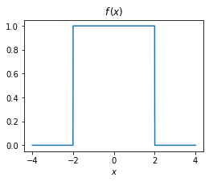

\begin{align*} \tilde f(q) &= \frac{1}{2\pi} \int_{-\infty}^\infty dx f(x) e^{-iqx} = \frac{1}{2\pi} \int_{-2}^{2} dx (1) e^{-iqx} \\ &= \frac{1}{2\pi} \left[ \frac{e^{-iqx}}{-iq}\right]^2_{-2} = -\frac{1}{q \pi}\frac{e^{-2qi}-e^{2qi}}{2i} = \frac{\sin(2q)}{q\pi} \end{align*} \begin{align*} f(x) &= \int_{-\infty}^\infty dq \tilde f(q) e^{iqx} = \int_{-\infty}^\infty dq \frac{\sin(2q)}{\pi q} (\cos (qx) + i \sin(qx)) \end{align*} Now note that * $\sin(2q)$ is an odd function of $q$. * $\dfrac{1}{\pi q} = \dfrac{1}{\pi} q^{-1}$ is also an odd function of $q$. * the interval of integration is symmetric about $0$. Therefore, $\sin(2q)/(\pi q)$ is an even function, and its product with an odd function (such as $\sin(qx))$ will integrate to $0$, leaving: $$ f(x) = \int_{-\infty}^\infty dq \frac{\sin(2q)}{\pi q} \cos(qx) $$

\begin{align*} f(x) &= \cos(3x) \\ \tilde f(q) &= \frac{1}{2\pi}\int_{-\infty}^\infty dq \cos(3x) e^{-iqx} \\ &= \frac{1}{2\pi} \int_{-\infty}^\infty dq \cos(3x) (\cos(qx) - i \sin(qx)) \end{align*}

The $i \sin(qx)$ term is odd and so contributes $0$ to the integral (since $\cos(3x)$ is even. That leaves \begin{align*} \tilde f(q) &= \frac{1}{2\pi} \int_{-\infty}^\infty dq \frac{e^{3x}+e^{-3x}}{2} \frac{e^{qx} + e^{-qx}}{2} \\ &= \frac{1}{8\pi} \int_{-\infty}^\infty dq \left[ e^{(3+q)x}+ e^{-(3+q)x} + e^{(3-q)x} + e^{-(3-q)x} \right]\\ &= \frac{1}{4\pi} \int_{-\infty}^\infty dq \left[ \cos(3+q) + \cos(3-q) \right] \end{align*} Let's be careful to not divide by zero. For $q \neq \pm 3$: \begin{align*} \tilde f(q) &= \frac{1}{4\pi} \left[\frac{\sin(3+q)}{3+q} + \frac{\sin(3-q)}{3-q} \right]^\infty_{-\infty} \\ &= 0 \end{align*} while for $q= \pm 3$: \begin{align*} \tilde f(\pm 3) &= \frac{1}{2\pi} \int_{-\infty}^\infty \cos(3x) \cos(\pm 3x) \\ &= \frac{1}{2\pi} \int_{-\infty}^\infty dx \cos^2 (3x) = \infty \end{align*}

What does this example show us? The Fourier transform of a simple harmonic oscillation, with periodicity $L=2\pi/3$, is an infinite spike at $q=3=2\pi/L$, and zero everywhere else.

What about for more general $f(x)$? Note that the Fourier transform is *linear*:

\begin{align*} f(x) &= g(x) + c h(x) \\ \tilde f(q) &= \frac{1}{2\pi} \int_{-\infty}^\infty dq f(x) e^{iqx} = \frac{1}{2\pi} \int_{-\infty}^\infty dq g(x) e^{iqx} + c \int_{-\infty}^\infty dq h(x) e^{iqx} \\ &= \tilde g(q) + c \tilde h(q) \quad \checkmark \end{align*}

So, we can think of any function $\tilde f(x)$ as a linear combination of SHO functions $\cos(qx)$ and $\sin(qx)$—or equivalently, $e^{iqx}$ and $e^{-iqx}$.

Now $q$ takes on the value of all real numbers, not just integers, so the linear combination *sum* becomes a linear combination *integral*: the inverse Fourier transform!

Meanwhile, the Fourier transform itself just takes the inner product of $f(x)$ with basis element $e^{iqx}$, that is, assigns to $\tilde f(q)$ the coefficient of $e^{iqx}$ when $f(x)$ is expanded in the $\{ e^{iqx} \}$ basis.

We therefore speak of the space of $q$-values as "frequency-space" (for functions of time) or "wavenumber space" (for functions of position). More generally, we can refer to $q$-space as *reciprocal space* or *Fourier space*.

## Parseval's Theorem for the Fourier transform

Let's find an analog of Parseval's Theorem, $$ \frac{1}{2\pi} \int_{-\pi}^\pi |f(x)|^2 = \sum_{n=-\infty}^\infty |c_n|^2 $$ for Fourier transforms.

First note that $|f(x)|^2 = f(x) (f(x))^*$. We can take the complex conjugate of \begin{align*} f(x) &= \int_{-\infty}^\infty dq \tilde f(q) e^{-iqx} \end{align*} to obtain \begin{align*} (f(x))^* &= \int_{-\infty}^\infty dq (\tilde f(q))^* e^{+iqx} \end{align*} So, \begin{align*} \frac{1}{2\pi} \int_{-\infty}^\infty dx |f(x)|^2 &= \frac{1}{2\pi} \int_{-\infty}^\infty dx \int_{-\infty}^\infty dq \tilde f(q) e^{-iqx} \int_{-\infty}^\infty dq' (\tilde f(q'))^* e^{+iq'x} \\ &= \frac{1}{2\pi} \int_{-\infty}^\infty dq \tilde f(q) \int_{-\infty}^\infty dq' (\tilde f(q'))^* \int_{-\infty}^\infty dx e^{i(q'-q) x} \end{align*}

Now, $ \dfrac{1}{2\pi} \int_{-\infty}^\infty dx e^{i(q'-q)x} $ is the Fourier transform of $g(x) = 1$, evaluated as $\tilde g(q'-q)$.

\begin{align*} \tilde g(q) &= \frac{1}{2\pi} \int_{-\infty}^\infty dx e^{iqx} = \begin{cases} \left. \frac{1}{2\pi} \frac{e^{iqx}}{iq} \right|^\infty_{-\infty} = 0 & q \neq 0 \\ \infty & q=0 \end{cases} \end{align*}

Hey, it's another Dirac delta function! $$\tilde g(q) = \delta(q-0)=\delta(q)$$ To check that we got the coefficient right: \begin{align*} g(x) = \int_{-\infty}^\infty dq \tilde g(q) e^{-iqx} = \int_{-\infty}^\infty dq \delta(q-0) e^{-iqx} = e^{-iq(0)} = 1 \quad \checkmark \end{align*}

Therefore, \begin{align*} \frac{1}{2\pi} \int_{-\infty}^\infty dx e^{i(q'-q)x} &= \tilde g(q'-q) = \delta(q'-q) \end{align*}

Thus, \begin{align*} \frac{1}{2\pi} \int_{-\infty}^\infty dx |f(x)|^2 &= \int_{-\infty}^\infty dq \tilde f(q) \int_{-\infty}^\infty dq' (\tilde f(q'))^* \delta(q'-q)\\ \end{align*} Now integrating over $q'$, the $\delta$ function "picks out" the value of $(\tilde f(q'))^*$ where $q'-q=0$, that is, $q'=q$:

\begin{align*} \frac{1}{2\pi} \int_{-\infty}^\infty dx |f(x)|^2 &= \int_{-\infty}^\infty dq \tilde f(q) (\tilde f(q))^* = \int_{-\infty}^\infty dq |\tilde f(q)|^2 \end{align*} This is Parseval's Theorem for Fourier transforms.

Suppose we know the Fourier transform $\tilde f(q)$ of $f(x)$. What is the Fourier transform of $h(x) = \dfrac{df}{dx}$? \begin{align*} \tilde h(q) &= \frac{1}{2\pi} \int_{-\infty}^\infty dx \dfrac{df}{dx} e^{iqx} = \frac{1}{2\pi} \left[ \int_{-\infty}^\infty dx \frac{d}{dx} \left(f(x) e^{iqx}\right) - \int_{-\infty}^\infty dx f(x) \frac{d}{dx} e^{iqx} \right] \\ \end{align*} Let's assume $f(x) \rightarrow 0$ as $x\rightarrow \pm \infty$: \begin{align*} \tilde h(q) &= \frac{1}{2\pi} \left[ {\left. f(x) e^{iqx} \right|^\infty_{-\infty}} - iq \int_{-\infty}^\infty dx f(x) e^{iqx} \right] \\ &= \frac{1}{2\pi} \left[ 0-0 - iq \int_{-\infty}^\infty dx f(x) e^{iqx} \right] \\ &= - i q \tilde f(q) \end{align*}

$$ h(x) = \dfrac{df}{dx} \Leftrightarrow \tilde h(q) = -iq \tilde f(q) $$ Differentiation in position-space becomes multiplication by $-iq$ in Fourier space!

We can iterate this result to get the Fourier transform of the $n$th derivative: Let $k(x) = dh/dx = d^2 f/dx^2$. Then

$$ \tilde k(q) = -iq \tilde h(q) = (-iq)^2 \tilde f(q) = -q^2 \tilde f(q)$$

and more generally,

$$ \text{ For $p(x) = d^n f/dx^n$, } \quad \tilde p(q) = (-iq)^n \tilde f(q).$$

This property can be very useful in solving differential equations "in Fourier space"... as long we can compute the inverse Fourier transform!

Example: *Solve the differential equation $\dfrac{d^2 f}{dx^2} = - 9 f$.* Taking the Fourier transforms of both sides, and exploiting linearity: \begin{align*} (-iq)^2 \tilde f(q) &= - 9 \tilde f(q) \\ \Rightarrow (9-q^2)\tilde f(q) &= 0 \end{align*} Since this equation is true for *all* $q$, $\tilde f(q)$ must vanish everywhere except $q=\pm 3$. So (for general complex coefficients $a$ and $b$) the general solution satisfies \begin{align*} \tilde f(q) &= a \delta(q+3) + b \delta(q-3) \\ \Rightarrow f(x) &= \int_{-\infty}^\infty dq \left(a \delta(q+3) + b\delta(q-3) \right) e^{-iqx} = a e^{3ix} + b e^{-3ix} \\ &= A \cos(3x) + i B \sin(3x) \end{align*} where $A=a+b$, $B=a-b$.

\begin{align*} \frac{df}{dx} &= \cos(3x) \\ \Rightarrow -iq \tilde f(q) &= \frac{1}{2} \left[ \delta(q+3) + \delta(q-3) \right] \\ \Rightarrow \tilde f(q) &= - \frac{1}{2iq} \left[ \delta(q+3) + \delta(q-3) \right] \\ \Rightarrow f(x) &= \int_{-\infty}^\infty dq \left(-\frac{1}{2iq} \left[\delta(q+3) + \delta(q-3) \right] \right) e^{-iqx} \\ &= \left(-\frac{1}{2i} \right) \left[ \int_{-\infty}^\infty dq \frac{e^{-iqx}}{q} \delta(q+3) + \int_{-\infty}^\infty dq \frac{e^{-iqx}}{q} \delta(q-3) \right] \\ &= \left(-\frac{1}{2i} \right) \left[ \frac{e^{3ix}}{-3} + \frac{e^{-3ix}}{3} \right] = \frac{1}{3} \sin(3x) \quad \checkmark \end{align*}